# Proyección del Tipo de Cambio Digital en Bolivia

Modelo ARIMAX — Inflación Interanual como Regresor Exógeno

Análisis Econométrico

17 de julio de 2026

# 1 Motivación

Espejo exacto de `ARIMAX_Inflacion.Rmd`, con los roles invertidos: aquí el **TC digital** es la variable a explicar, y la **inflación interanual** es el regresor exógeno. Se estima un ARIMA(p,d,q) base (sin exógena) y un ARIMAX(p,d,q)+inflación en paralelo sobre log(TC digital), y el backtesting decide cuál se usa para el pronóstico final — mismo criterio que el resto de la batería.

> **Nota de muestra:** el TC digital solo cotiza realmente desde oct-2023; se usa la ventana de meses completos noviembre 2023–junio 2026 (n=32), bastante más corta que la de los modelos de inflación.

# 2 Datos: TC Digital e Inflación Interanual

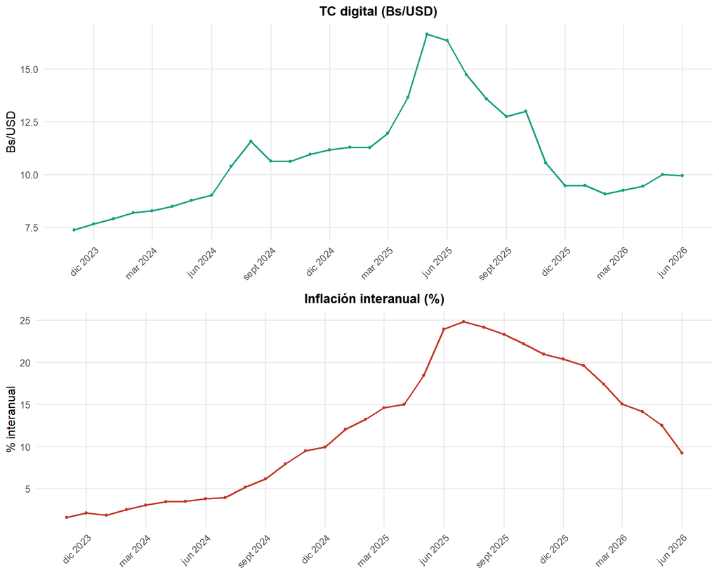

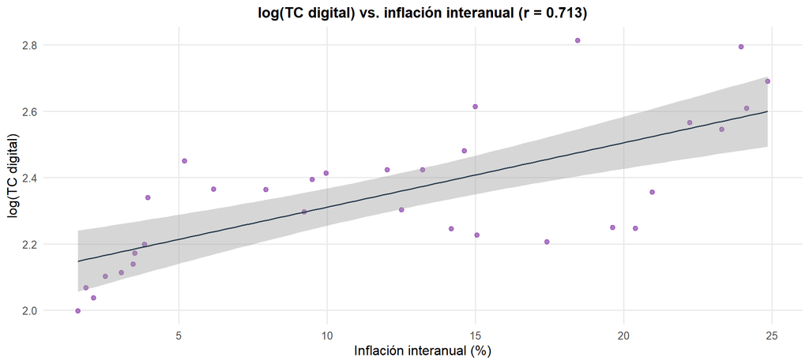

> Correlación en niveles: **r = 0.713**. Igual que en el reporte espejo, una correlación en niveles no implica relación causal ni predictiva de corto plazo — de ahí el backtesting.

# 3 Identificación y Estacionariedad

Pruebas de raíz unitaria

| Prueba | Serie | Estadístico | p-valor | Conclusión |
| --- | --- | --- | --- | --- |
| **log(TC digital)** |  |  |  |  |
| ADF | log(TC digital) | -1.5195 | 0.7582 | No estac. |
| Phillips-Perron | log(TC digital) | -3.5495 | 0.9054 | No estac. |
| KPSS | log(TC digital) | 0.3251 | 0.1000 | Estac. |
| Zivot-Andrews | log(TC digital) | -4.1681 | 0.1000 | No estac. |
| **Δlog(TC)** |  |  |  |  |
| ADF | Δlog(TC) | -2.4585 | 0.3962 | No estac. |
| Phillips-Perron | Δlog(TC) | -19.0781 | 0.0406 | Estac. |
| KPSS | Δlog(TC) | 0.2739 | 0.1000 | Estac. |
| Zivot-Andrews | Δlog(TC) | -3.2056 | 0.1000 | No estac. |
| **Inflación interanual (regresor)** |  |  |  |  |
| ADF | Inflación ia | -0.4494 | 0.9780 | No estac. |
| KPSS | Inflación ia | 0.6409 | 0.0189 | No estac. |

> Zivot-Andrews: quiebre en **oct 2025** (log(TC)) y **jun 2025** (Δlog(TC)). Igual que en el reporte espejo, la inflación como regresor se maneja vía regresión con errores ARMA, no como cointegración formal.

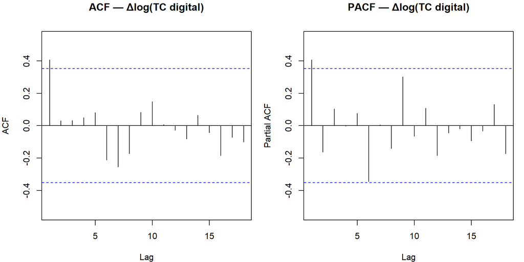

# 4 Estimación y Selección — ARIMA base vs. ARIMAX

Ambas grillas recorren $p,q \in [0,4]$, $d \in \{0,1\}$ sobre **log(TC digital)**; la única diferencia es la presencia del regresor `Inf_ia` (inflación interanual).

## 4.1 ARIMA base (sin exógena)

ARIMA base — Top 15 de 49 modelos (log TC digital, sin regresor)

| Modelo | d | AICc | BIC | HQ | RMSE | MAPE | LB12(p) | Raices | Score |
| --- | --- | --- | --- | --- | --- | --- | --- | --- | --- |
| ARIMA(2,1,3) | 1 | -69.24 | -64.14 | -69.93 | 0.05471 | 1.584 | 0.6385 | OK | -2.361 |
| ARIMA(1,1,1) | 1 | -72.80 | -69.38 | -72.28 | 0.06390 | 1.869 | 0.6085 | OK | -1.791 |
| ARIMA(3,1,2) | 1 | -67.97 | -62.87 | -68.67 | 0.05722 | 1.635 | 0.3560 | OK | -1.761 |
| ARIMA(2,1,4) | 1 | -66.02 | -60.85 | -67.62 | 0.05453 | 1.577 | 0.5635 | OK | -1.743 |
| ARIMA(2,1,1) | 1 | -70.77 | -66.58 | -70.44 | 0.06262 | 1.779 | 0.5715 | OK | -1.621 |
| ARIMA(3,0,3) | 0 | -64.28 | -58.82 | -66.65 | 0.05425 | 1.569 | 0.2123 | OK | -1.526 |
| ARIMA(1,1,2) | 1 | -70.57 | -66.37 | -70.24 | 0.06280 | 1.798 | 0.5737 | OK | -1.519 |
| ARIMA(0,1,2) | 1 | -71.95 | -68.53 | -71.43 | 0.06520 | 1.931 | 0.3690 | OK | -1.357 |
| ARIMA(0,1,1) | 1 | -72.64 | -70.20 | -72.14 | 0.06823 | 1.953 | 0.4343 | OK | -1.322 |
| ARIMA(0,1,3) | 1 | -70.43 | -66.23 | -70.10 | 0.06368 | 1.866 | 0.4350 | OK | -1.232 |
| ARIMA(4,0,2) | 0 | -63.88 | -58.41 | -66.25 | 0.05578 | 1.614 | 0.0926 | OK | -1.188 |
| ARIMA(3,0,2) | 0 | -66.27 | -60.68 | -67.54 | 0.05823 | 1.727 | 0.0533 | OK | -1.140 |
| ARIMA(1,1,3) | 1 | -68.02 | -63.25 | -68.08 | 0.06248 | 1.761 | 0.4866 | OK | -1.050 |
| ARIMA(2,0,1) | 0 | -69.11 | -64.09 | -68.99 | 0.06353 | 1.846 | 0.2478 | OK | -1.041 |
| ARIMA(3,0,1) | 0 | -67.20 | -61.76 | -67.64 | 0.06162 | 1.742 | 0.2220 | OK | -1.032 |

> **Ganador:** ARIMA(2,1,3) (Score = -2.361)

## 4.2 ARIMAX (+ inflación interanual)

ARIMAX — Top 15 de 49 modelos (log TC digital + inflación interanual)

| Modelo | d | AICc | BIC | HQ | RMSE | MAPE | LB12(p) | Raices | Score |
| --- | --- | --- | --- | --- | --- | --- | --- | --- | --- |
| ARIMA(2,0,1) | 0 | -71.08 | -65.64 | -71.52 | 0.05943 | 1.649 | 0.1248 | OK | -1.779 |
| ARIMA(0,0,3) | 0 | -71.33 | -65.90 | -71.78 | 0.05826 | 1.742 | 0.2040 | OK | -1.615 |
| ARIMA(3,0,1) | 0 | -68.43 | -62.84 | -69.70 | 0.05795 | 1.561 | 0.0708 | OK | -1.604 |
| ARIMA(1,0,2) | 0 | -70.65 | -65.22 | -71.10 | 0.05999 | 1.666 | 0.0831 | OK | -1.499 |
| ARIMA(1,1,1) | 1 | -72.62 | -68.43 | -72.29 | 0.06136 | 1.787 | 0.3234 | OK | -1.453 |
| ARIMA(2,0,2) | 0 | -68.07 | -62.47 | -69.33 | 0.05855 | 1.600 | 0.0885 | OK | -1.236 |
| ARIMA(1,0,3) | 0 | -68.75 | -63.16 | -70.02 | 0.05741 | 1.683 | 0.1267 | OK | -1.227 |
| ARIMA(0,0,4) | 0 | -68.80 | -63.21 | -70.07 | 0.05720 | 1.701 | 0.1372 | OK | -1.193 |
| ARIMA(0,1,2) | 1 | -72.09 | -67.89 | -71.76 | 0.06227 | 1.824 | 0.2415 | OK | -1.000 |
| ARIMA(0,1,4) | 1 | -68.04 | -62.93 | -68.73 | 0.05922 | 1.626 | 0.3387 | OK | -0.980 |
| ARIMA(2,1,1) | 1 | -69.88 | -65.11 | -69.94 | 0.06057 | 1.740 | 0.2368 | OK | -0.874 |
| ARIMA(1,1,2) | 1 | -69.87 | -65.10 | -69.94 | 0.06058 | 1.746 | 0.2441 | OK | -0.845 |
| ARIMA(3,0,2) | 0 | -68.57 | -63.10 | -70.94 | 0.05266 | 1.481 | 0.0195 | OK | -0.806 |
| ARIMA(1,0,4) | 0 | -65.72 | -60.26 | -68.10 | 0.05701 | 1.602 | 0.0789 | OK | -0.802 |
| ARIMA(2,0,3) | 0 | -65.27 | -59.80 | -67.64 | 0.05751 | 1.595 | 0.0503 | OK | -0.629 |

> **Ganador:** ARIMA(2,0,1)+Inf_ia (Score = -1.779)

Coeficiente del regresor exógeno (inflación interanual) en el ARIMAX ganador

| Variable | Coeficiente | Err. Std. | z | p-valor |
| --- | --- | --- | --- | --- |
| Inf_ia | 0.01816 | 0.00666 | 2.727 | 0.0064 |

> El coeficiente de la inflación interanual es significativo al 5%, por lo que la elección final entre ARIMA base y ARIMAX se decide con el **backtesting** (siguiente sección), no con el ajuste dentro de muestra.

## 4.3 Comparación dentro de muestra

Base: ARIMA(2,1,3) vs ARIMAX: ARIMA(2,0,1)+Inf_ia

| Criterio | Base | ARIMAX |
| --- | --- | --- |
| Especificación | ARIMA(2,1,3) | ARIMA(2,0,1)+Inf_ia |
| AIC | -72.74 | -74.44 |
| BIC | -64.14 | -65.64 |
| AICc | -69.24 | -71.08 |
| Hannan-Quinn | -69.93 | -71.52 |
| RMSE (train) | 0.054708 | 0.059434 |
| MAPE (train) | 1.5838 | 1.6492 |
| Ljung-Box h=12 (p) | 0.6385 | 0.1248 |

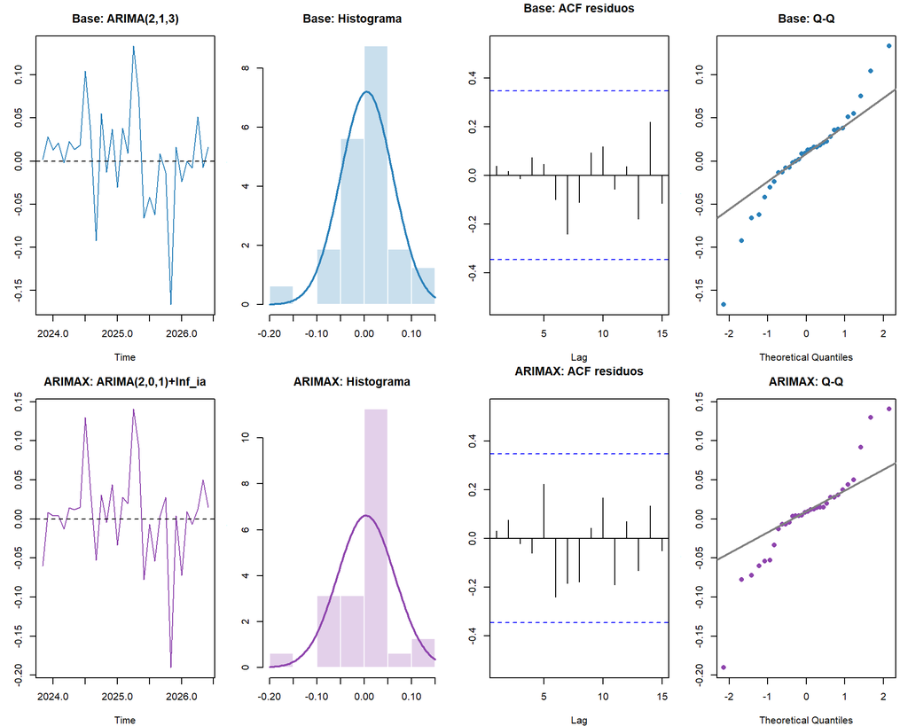

# 5 Backtesting

Se reservan los últimos 6 meses; ambos modelos se re-estiman solo con datos de entrenamiento y se comparan en **niveles de TC digital**. Para el ARIMAX se usa la inflación interanual efectivamente observada en esos meses. **Este es el criterio decisivo** para elegir el modelo final.

Backtesting — TC digital observado vs. pronosticado

| Fecha | TC obs. | Base pron. | ARIMAX pron. | Err. Base | Err. ARIMAX |
| --- | --- | --- | --- | --- | --- |
| ene 2026 | 9.4736 | 10.4317 | 10.3857 | 0.9581 | 0.9121 |
| feb 2026 | 9.0775 | 10.4005 | 10.3124 | 1.3230 | 1.2349 |
| mar 2026 | 9.2585 | 10.2761 | 10.1815 | 1.0176 | 0.9230 |
| abr 2026 | 9.4446 | 10.2073 | 10.2451 | 0.7627 | 0.8005 |
| may 2026 | 10.0009 | 10.2317 | 10.0775 | 0.2309 | 0.0767 |
| jun 2026 | 9.9393 | 10.2898 | 9.5494 | 0.3505 | -0.3899 |

Métricas de backtesting comparadas

| Métrica | ARIMA base | ARIMAX |
| --- | --- | --- |
| RMSE (TC) | 0.8623 | 0.8173 |
| MAPE (%) | 8.26% | 7.73% |

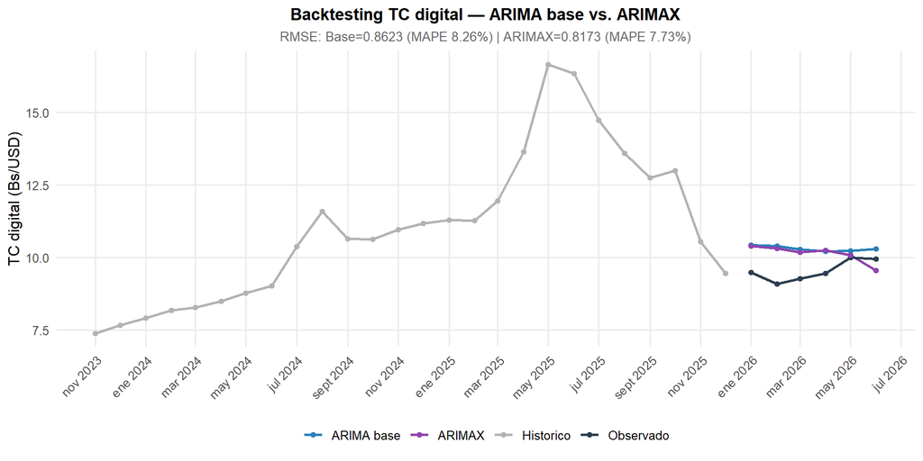

> **Modelo elegido: ARIMAX (+inflación) (ARIMA(2,0,1)+Inf_ia).** RMSE fuera de muestra: Base = 0.8623 vs ARIMAX = 0.8173 (MAPE: 8.26% vs 7.73%). La inflación interanual mejora la capacidad predictiva fuera de muestra, así que el pronóstico final usa el ARIMAX.

# 6 Pronóstico Final

## 6.1 Proyección comparada

Proyección de TC digital — Base: ARIMA(2,1,3) vs ARIMAX: ARIMA(2,0,1)+Inf_ia

| Mes | Base (TC digital) | ARIMAX (TC digital) |
| --- | --- | --- |
| Julio | 10.1268 | 9.9243 |
| Agosto | 10.1827 | 9.8913 |
| Septiembre | 10.0240 | 9.8710 |
| Octubre | 10.2500 | 9.8536 |
| Noviembre | 10.0037 | 9.8402 |
| Diciembre | 10.2237 | 9.8296 |
| Enero | 10.0674 | 9.8213 |

## 6.2 Fan chart — modelo elegido (ARIMAX (+inflación))

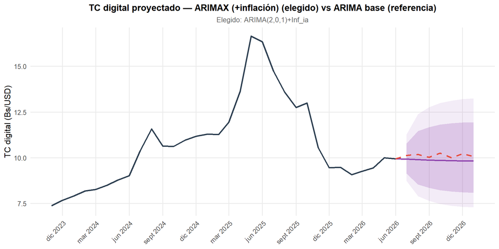

*Modelos estimados sobre log(TC digital) desde nov 2023 (n=32). Regresor exógeno: inflación interanual.* *Scoring compuesto: RMSE + MAPE + (AICc + BIC + HQ)/3 + 0.3·Complejidad + penalizaciones LB y raíces — usado solo para elegir el mejor (p,d,q) dentro de cada familia.* *La elección entre ARIMA base y ARIMAX es por backtesting (fuera de muestra): modelo final = **ARIMA(2,0,1)+Inf_ia** (ARIMAX (+inflación)).*